# Project 2

For this project, a csv file containing information about launched satellites over the world was imported into the RestfulOracleDatabase. The data included the country of origin, it’s purpose, and various other information.

## Importing Dataframe

The first step is to import libraries needed for this project:

```r
source("../.Rprofile", echo=TRUE)
```

```
##
## > library("bitops", lib.loc = "/Library/Frameworks/R.framework/Versions/3.1/Resources/library")
##
## > library("ggplot2", lib.loc = "/Library/Frameworks/R.framework/Versions/3.1/Resources/library")
##
## > library("gplots", lib.loc = "/Library/Frameworks/R.framework/Versions/3.1/Resources/library")
```

```
##
## > library("plyr", lib.loc = "/Library/Frameworks/R.framework/Versions/3.1/Resources/library")
##
## > library("grid", lib.loc = "/Library/Frameworks/R.framework/Versions/3.1/Resources/library")
##
## > library("RCurl", lib.loc = "/Library/Frameworks/R.framework/Versions/3.1/Resources/library")
##
## > library("reshape2", lib.loc = "/Library/Frameworks/R.framework/Versions/3.1/Resources/library")
##
## > library("tidyr", lib.loc = "/Library/Frameworks/R.framework/Versions/3.1/Resources/library")
##
## > library("dplyr", lib.loc = "/Library/Frameworks/R.framework/Versions/3.1/Resources/library")
```

Next, we will build our dataframe. We grab the data from the Oracle Database with a SQL query. The following dataframe shown is the head of the whole dataframe

```r
source("../01_Data/Dataframes.R", echo=TRUE)
```

```
##
## > df <- data.frame(eval(parse(text = substring(getURL(URLencode("http://129.152.144.84:5001/rest/native/?query=\"select * from SATELLITE\""),
## +     h .... [TRUNCATED]
##
## > head(df)
##                                                     SATELLITENAME COUNTRY
## 1                            Advanced Orion 6 (NRO L-15, USA 237)     USA
## 2 AEHF-1 (Advanced Extremely High Frequency satellite-1, USA 214)     USA
## 3 AEHF-2 (Advanced Extremely High Frequency satellite-2, USA 235)     USA
## 4 AEHF-3 (Advanced Extremely High Frequency satellite-3, USA 246)     USA
## 5                                                          Aeneas     USA
## 6                                                   Aerocube 4.5A     USA
##                                  OWNER      USERS                 PURPOSE
## 1 National Reconnaissance Office (NRO)   Military Electronic Surveillance
## 2                         US Air Force   Military          Communications
```

[output cut: 74 more lines]

## Data Wrangling

We can now use data wrangling to modify and filter out the raw data into dataframes that allows for analysis

This data set shows the number of satellite launched from the countries with the 10 most number of launches

```r
source("../02_DataWrangling/Wrangle1.R", echo=TRUE)
```

```
##
## > wdf1 <- df %>% select(COUNTRY) %>% group_by(COUNTRY) %>%
## +     summarise(CountryAmount = n()) %>% top_n(10)
```

```
##
## > head(wdf1)
## Source: local data frame [6 x 2]
##
##      COUNTRY CountryAmount
## 1     Canada            27
## 2 China (PR)           103
## 3        ESA            19
## 4    Germany            23
## 5      India            29
## 6      Japan            51
```

This data set shows the user of those satellites from the top 10 countries with launches. The satellites that are belong to multiple users are ommitted.

```r
source("../02_DataWrangling/Wrangle2.R", echo=TRUE)
```

```
##
## > wdf2 <- df %>% select(USERS, COUNTRY) %>% group_by(COUNTRY,
## +     USERS) %>% summarise(n = n()) %>% filter(COUNTRY %in% c("USA",
## +     "China (PR) ..." ... [TRUNCATED]
##
## > head(wdf2)
## Source: local data frame [6 x 3]
## Groups: COUNTRY
##
##      COUNTRY      USERS  n
## 1     Canada      Civil  4
## 2     Canada Commercial 17
## 3     Canada Government  4
## 4     Canada   Military  1
## 5 China (PR)      Civil  5
## 6 China (PR) Commercial  9
```

This data set shows the launch dates of each of the satellites from the top 10 contry with the most launches. There are a few satellites that are missing this data, so they are omitted.

```r
source("../02_DataWrangling/Wrangle3.R", echo=TRUE)
```

```
##
## > wdf3 <- df %>% select(LAUNCHDATE, COUNTRY) %>% group_by(COUNTRY,
## +     LAUNCHDATE) %>% filter(COUNTRY %in% c("USA", "China (PR)",
## +     "Russia",  .... [TRUNCATED]
##
## > head(wdf3)
## Source: local data frame [6 x 2]
## Groups: COUNTRY, LAUNCHDATE
##
##   LAUNCHDATE COUNTRY
## 1    6/29/12     USA
## 2    8/14/10     USA
## 3     5/3/12     USA
## 4    9/18/13     USA
## 5    9/13/12     USA
## 6    9/13/12     USA
```

## Visualization

Out of the top 10 countries, the US alone overshadowed the other 9 countries combined in the number of satellite launched

```r
source("../03_Visualizations/Visualize1.R", echo=TRUE)
```

```
##
## > wdf1 %>% ggplot(aes(x = COUNTRY, y = CountryAmount)) +
## +     geom_bar(stat = "identity")
```

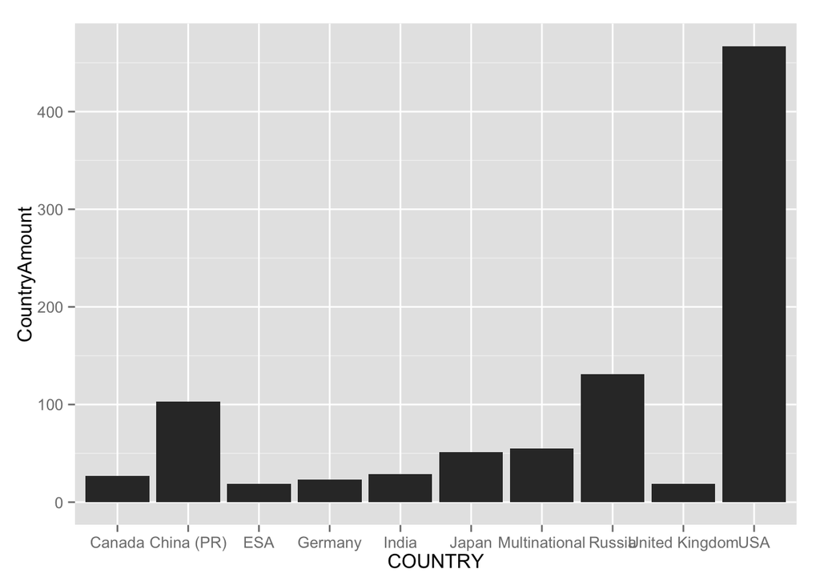

```r
source("../03_Visualizations/Visualize2.R", echo=TRUE)
```

```
##
## > wdf2 %>% ggplot(aes(x = USERS, y = n, color = USERS)) +
## +     geom_bar(stat = "identity") + facet_wrap(~COUNTRY)
```

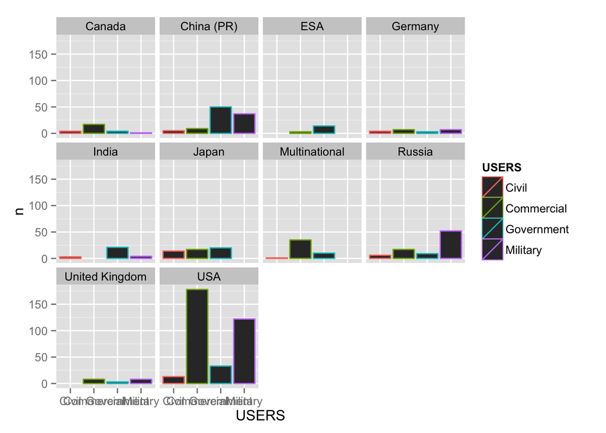

```r
source("../03_Visualizations/Visualize3.R", echo=TRUE)
```

```
##
## > wdf3 %>% ggplot(aes(x = COUNTRY, y = as.Date(LAUNCHDATE,
## +     "%Y/%m/%d"))) + geom_point()
```

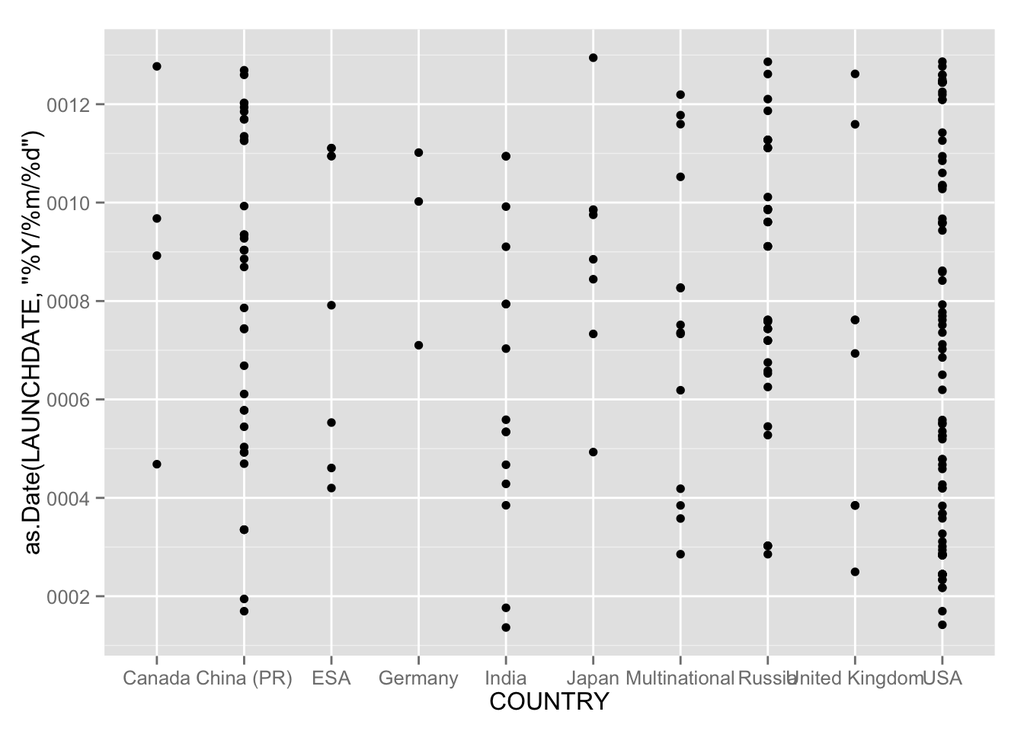